# 03 - Biomass recovery without spatial recovery

Results 2.1: change-point, hysteresis, matched-biomass contrast, and the survey-rescaling sensitivity (Supplementary Table S1)

Sarah Ohayon, Jacob T. Dingwall, Amanda E. Bates

2026-10-01

Every statistic reported in Results §2.1 is produced here. The argument has four steps:

1. the occupancy series contains an abrupt structural break, independent of any phase we impose;
2. once that break is accounted for, biomass has no detectable effect on occupancy;
3. contrasting the two phases *at equivalent biomass* shows the same gap;
4. the conclusion survives any plausible rescaling of the older surface-survey index (**Supplementary Table S1**), including corrections large enough to erase the apparent biomass recovery altogether.

```r
annual    <- read_csv(file.path(DERIVED, "annual_series.csv"), show_col_types = FALSE)
site_year <- read_csv(file.path(DERIVED, "site_year_spawn.csv"), show_col_types = FALSE)

d <- annual %>%
  select(Year, n_active, occupancy, SSB) %>%
  filter(!is.na(occupancy)) %>%
  mutate(SSBk  = SSB/1000,
         phase = factor(if_else(Year < BREAK_YEAR, "Pre-collapse", "Post-collapse"),
                        levels = c("Pre-collapse","Post-collapse"))) %>%
  arrange(Year)

N_all <- round(unique(d$n_active / d$occupancy)[1])
cat(sprintf("Occupancy denominator N_all = %d sections; series %d-%d (n = %d years)\n",
            N_all, min(d$Year), max(d$Year), nrow(d)))
```

```
## Occupancy denominator N_all = 19 sections; series 1951-2024 (n = 74 years)
```

## 1 The occupancy series contains a structural break

A supF test asks whether *any* break is present; the BIC-optimal single-break model then locates it and returns a 95% confidence interval. Neither uses the 1984 boundary as an input, so the break year is estimated, not assumed.

```r
sc <- sctest(d$occupancy ~ 1, type = "supF")
print(sc)
```

```
##
##  supF test
##
## data:  d$occupancy ~ 1
## sup.F = 187.31, p-value < 2.2e-16
```

```r
bp <- breakpoints(d$occupancy ~ 1, breaks = 1)
ci <- confint(bp, breaks = 1)$confint

cat(sprintf("\nBreak after %d (new regime from %d); 95%% CI %d-%d\n",
            d$Year[bp$breakpoints], d$Year[bp$breakpoints + 1],
            d$Year[ci[1]], d$Year[ci[3]]))
```

```
##
## Break after 1978 (new regime from 1979); 95% CI 1977-1980
```

```r
cat(sprintf("supF = %.0f, P %s\n", sc$statistic, fmt_p(sc$p.value)))
```

```
## supF = 187, P < 0.001
```

```r
cat(sprintf("\nLargest single-year decline: %d -> %d, %d -> %d occupied sections\n",
            1983, 1984, d$n_active[d$Year == 1983], d$n_active[d$Year == 1984]))
```

```
##
## Largest single-year decline: 1983 -> 1984, 9 -> 6 occupied sections
```

```r
pre  <- d %>% filter(phase == "Pre-collapse")
post <- d %>% filter(phase == "Post-collapse")
cat(sprintf("Pre-collapse  (<=%d): %.1f +/- %.1f sections (%.0f%%)\n",
            BREAK_YEAR-1, mean(pre$n_active), sd(pre$n_active), 100*mean(pre$occupancy)))
```

```
## Pre-collapse  (<=1983): 12.6 +/- 2.5 sections (66%)
```

```r
cat(sprintf("Post-collapse (>=%d): %.1f +/- %.1f sections (%.0f%%)\n",
            BREAK_YEAR, mean(post$n_active), sd(post$n_active), 100*mean(post$occupancy)))
```

```
## Post-collapse (>=1984): 6.3 +/- 1.6 sections (33%)
```

```r
cat(sprintf("Decline in occupied sections: %.0f%%\n",
            100*(mean(pre$n_active) - mean(post$n_active))/mean(pre$n_active)))
```

```
## Decline in occupied sections: 50%
```

### The contraction precedes the change in survey method

Dive surveys began in the Strait of Georgia in 1985 and immediately dominated the index. The contraction occurred in 1984, while every spawn record in the Strait was still a surface survey - so it cannot be an artefact of the method transition.

```r
spawn_raw <- read_csv(F_SPAWN, show_col_types = FALSE) %>%
  mutate(StatisticalArea = suppressWarnings(as.numeric(StatisticalArea))) %>%
  keep_surveyed()   # presence rule, 00_setup.R
meth <- spawn_raw %>% filter(Region == SOG_REGION, StatisticalArea %in% OCC_AREAS, !is.na(Year)) %>%
  mutate(period = if_else(Year <= 1984, "1951-1984", "1985-2025"),
         bio_surface   = replace_na(Surface, 0),
         bio_under     = replace_na(Understory, 0),
         bio_macro     = replace_na(Macrocystis, 0))
meth %>% group_by(period) %>%
  summarise(n_records = n(),
            pct_surface_derived   = 100*sum(bio_surface)/sum(bio_surface+bio_under+bio_macro),
            pct_understory_derived= 100*sum(bio_under)  /sum(bio_surface+bio_under+bio_macro),
            .groups = "drop") %>%
  mutate(across(where(is.numeric), ~round(., 1))) %>%
  kable(caption = "Share of egg deposition by survey component, before and after the 1985 dive-survey transition")
```

Share of egg deposition by survey component, before and after the 1985 dive-survey transition

| period | n_records | pct_surface_derived | pct_understory_derived |
| --- | --- | --- | --- |
| 1951-1984 | 3436 | 100.0 | 0.0 |
| 1985-2025 | 2173 | 1.6 | 98.4 |

```r
## records of more than one spawn event per location-year, before vs after
multi <- spawn_raw %>% filter(Region == SOG_REGION, StatisticalArea %in% OCC_AREAS) %>%
  count(LocationCode, Year) %>%
  group_by(Year) %>% summarise(pct_multi = 100*mean(n > 1), .groups = "drop") %>%
  filter(Year %in% 1951:2024) %>% arrange(Year)
sc_multi <- sctest(multi$pct_multi ~ 1, type = "supF")
bp_multi <- breakpoints(multi$pct_multi ~ 1, breaks = 1)
cat(sprintf("Multiple spawn records per location-year: structural break after %d (supF = %.0f, P %s)\n",
            multi$Year[bp_multi$breakpoints], sc_multi$statistic, fmt_p(sc_multi$p.value)))
```

```
## Multiple spawn records per location-year: structural break after 1985 (supF = 290, P < 0.001)
```

```r
cat(sprintf("  mean %% of location-years with >1 record: before %.0f%%, after %.0f%%\n",
            mean(multi$pct_multi[multi$Year <= multi$Year[bp_multi$breakpoints]]),
            mean(multi$pct_multi[multi$Year >  multi$Year[bp_multi$breakpoints]])))
```

```
##   mean % of location-years with >1 record: before 50%, after 12%
```

## 2 Biomass does not explain occupancy once the phase is accounted for

```r
m_hyst <- lm(occupancy ~ scale(SSB) + phase, data = d)
print(round(summary(m_hyst)$coefficients, 4))
```

```
##                    Estimate Std. Error  t value Pr(>|t|)
## (Intercept)          0.6557     0.0197  33.3518   0.0000
## scale(SSB)          -0.0138     0.0137  -1.0038   0.3189
## phasePost-collapse  -0.3182     0.0274 -11.5982   0.0000
```

```r
p_ssb   <- summary(m_hyst)$coefficients["scale(SSB)", "Pr(>|t|)"]
p_phase <- summary(m_hyst)$coefficients[grep("^phase", rownames(summary(m_hyst)$coefficients)),
                                        "Pr(>|t|)"]
cat(sprintf("\nSSB: P %s | collapse phase: P %s\n", fmt_p(p_ssb), fmt_p(p_phase)))
```

```
##
## SSB: P = 0.319 | collapse phase: P < 0.001
```

```r
cat(sprintf("Mean SSB: pre %.0f kt, post %.0f kt (post/pre = %.2f)\n",
            mean(pre$SSBk), mean(post$SSBk), mean(post$SSBk)/mean(pre$SSBk)))
```

```
## Mean SSB: pre 49 kt, post 75 kt (post/pre = 1.53)
```

```r
cat(sprintf("Peak SSB: %.0f kt in %d; pre-collapse maximum %.0f kt in %d\n",
            max(d$SSBk), d$Year[which.max(d$SSBk)],
            max(pre$SSBk), pre$Year[which.max(pre$SSBk)]))
```

```
## Peak SSB: 152 kt in 2003; pre-collapse maximum 111 kt in 1953
```

```r
cat(sprintf("Minimum SSB: %.0f kt in %d, occupancy that year = %.0f%%\n",
            min(d$SSBk), d$Year[which.min(d$SSBk)], 100*d$occupancy[which.min(d$SSBk)]))
```

```
## Minimum SSB: 7 kt in 1966, occupancy that year = 68%
```

### Matched-biomass contrast

Because the two phases differ in mean biomass, the phase effect is re-examined over the range of SSB actually observed before the collapse, so that pre- and post-collapse years are contrasted at equivalent biomass.

```r
matched_contrast <- function(dat) {
  rng <- range(dat$SSB[dat$phase == "Pre-collapse"])
  a <- dat %>% filter(phase == "Pre-collapse")
  b <- dat %>% filter(phase == "Post-collapse", SSB >= rng[1], SSB <= rng[2])
  tibble(occ_pre = mean(a$occupancy), n_pre = nrow(a),
         occ_post_matched = mean(b$occupancy), n_post_matched = nrow(b))
}
mc <- matched_contrast(d)
cat(sprintf("At equivalent biomass: pre %.0f%% (n = %d) vs post %.0f%% (n = %d)\n",
            100*mc$occ_pre, mc$n_pre, 100*mc$occ_post_matched, mc$n_post_matched))
```

```
## At equivalent biomass: pre 66% (n = 33) vs post 33% (n = 35)
```

## 3 Supplementary Table S1 - sensitivity to rescaling the surface-survey index

Surface and dive surveys are not on the same scale: surface surveys used subjective intensity categories before 1978 and systematically underestimate spawn width, a direct multiplier on biomass. DFO estimates separate index scaling parameters for the two periods (q₁, q₂). The comparison above is therefore repeated with the surface-era index (≤ 1987, DFO’s q₁ period) multiplied by a factor *k* spanning the full plausible range - from no correction (k = 1) up to and beyond the value that **eliminates the apparent recovery entirely**, i.e. that makes mean pre-collapse biomass equal mean post-collapse biomass.

```r
k_equalise <- mean(post$SSB) / mean(pre$SSB)
cat(sprintf("k that equalises pre- and post-collapse mean SSB: %.2f\n", k_equalise))
```

```
## k that equalises pre- and post-collapse mean SSB: 1.53
```

```r
k_grid <- sort(unique(round(c(1, 1.25, 1.5, k_equalise, 2, 2.5, 3), 2)))

tabS1 <- map_dfr(k_grid, function(k) {
  dk <- d %>% mutate(SSB = if_else(Year <= 1987, SSB * k, SSB), SSBk = SSB/1000)
  m  <- lm(occupancy ~ scale(SSB) + phase, data = dk)
  cf <- summary(m)$coefficients
  mc <- matched_contrast(dk)
  pk <- dk %>% filter(phase == "Pre-collapse"); qk <- dk %>% filter(phase == "Post-collapse")
  tibble(`Surface-era scaling k`     = k,
         `Mean pre-collapse SSB (kt)`  = round(mean(pk$SSBk)),
         `Mean post-collapse SSB (kt)` = round(mean(qk$SSBk)),
         `Post/pre biomass ratio`      = round(mean(qk$SSBk)/mean(pk$SSBk), 2),
         `SSB P`   = signif(cf["scale(SSB)","Pr(>|t|)"], 2),
         `Phase P` = signif(cf[grep("^phase", rownames(cf)),"Pr(>|t|)"], 2),
         `Occupancy pre (%)`               = round(100*mc$occ_pre),
         `Occupancy post, matched SSB (%)` = round(100*mc$occ_post_matched),
         `n matched post-collapse years`   = mc$n_post_matched)
})

save_tab(tabS1, "TableS1_survey_rescaling_sensitivity")

## Supplementary Table S7 (break and decoupling columns): the same statistics under three
## rules for which spawn records count as presence (series written by 01). 05 adds the GAMM.
occ_rules <- read_csv(file.path(DERIVED, "occupancy_rule_sensitivity.csv"), show_col_types = FALSE) %>%
  filter(Year %in% d$Year) %>%
  left_join(d %>% select(Year, SSB), by = "Year") %>%
  mutate(phase = factor(if_else(Year < BREAK_YEAR, "Pre-collapse", "Post-collapse"),
                        levels = c("Pre-collapse", "Post-collapse")))
tabS7a <- occ_rules %>% group_by(rule) %>% group_modify(function(x, k) {
  x  <- arrange(x, Year)
  sc <- sctest(x$occupancy ~ 1, type = "supF")
  bp <- breakpoints(x$occupancy ~ 1, breaks = 1)
  ci <- tryCatch(confint(bp, breaks = 1)$confint, error = function(e) c(NA, NA, NA))
  cf <- summary(lm(occupancy ~ scale(SSB) + phase, data = x))$coefficients
  mc <- matched_contrast(x)
  tibble(Sections = x$n_sections[1],
         supF     = round(sc$statistic),
         `Break (95% CI)` = sprintf("after %d (%d-%d)", x$Year[bp$breakpoints], x$Year[ci[1]], x$Year[ci[3]]),
         `Occupancy pre (%)`  = round(100*mean(x$occupancy[x$phase == "Pre-collapse"])),
         `Occupancy post (%)` = round(100*mean(x$occupancy[x$phase == "Post-collapse"])),
         `Occupancy post, matched SSB (%)` = round(100*mc$occ_post_matched),
         `SSB P`   = signif(cf["scale(SSB)", "Pr(>|t|)"], 2),
         `Phase P` = signif(cf["phasePost-collapse", "Pr(>|t|)"], 2))
}) %>% ungroup()
save_tab(tabS7a, "TableS7_occupancy_rule_part_decoupling")
kable(tabS7a, caption = "Occupancy decoupling under three presence rules")
```

Occupancy decoupling under three presence rules

| rule | Sections | supF | Break (95% CI) | Occupancy pre (%) | Occupancy post (%) | Occupancy post, matched SSB (%) | SSB P | Phase P |
| --- | --- | --- | --- | --- | --- | --- | --- | --- |
| All spawn records | 19 | 117 | after 1977 (1975-1979) | 66 | 39 | 38 | 0.68 | 0 |
| Spawn biomass > 0 only | 18 | 208 | after 1982 (1981-1984) | 68 | 34 | 33 | 0.40 | 0 |
| Surveyed spawn records (main analysis) | 19 | 187 | after 1978 (1977-1980) | 66 | 33 | 33 | 0.32 | 0 |

```r
kable(tabS1, caption = paste(
  "Supplementary Table S1. Sensitivity of the biomass-occupancy decoupling to rescaling of",
  "the surface-survey era (<= 1987) spawn index. k = 1 is the published index;",
  sprintf("k = %.2f equalises mean pre- and post-collapse biomass, eliminating the", k_equalise),
  "apparent recovery. Occupancy is compared over the range of SSB observed before the collapse."))
```

Supplementary Table S1. Sensitivity of the biomass-occupancy decoupling to rescaling of the surface-survey era (<= 1987) spawn index. k = 1 is the published index; k = 1.53 equalises mean pre- and post-collapse biomass, eliminating the apparent recovery. Occupancy is compared over the range of SSB observed before the collapse.

| Surface-era scaling k | Mean pre-collapse SSB (kt) | Mean post-collapse SSB (kt) | Post/pre biomass ratio | SSB P | Phase P | Occupancy pre (%) | Occupancy post, matched SSB (%) | n matched post-collapse years |
| --- | --- | --- | --- | --- | --- | --- | --- | --- |
| 1.00 | 49 | 75 | 1.53 | 0.320 | 0 | 66 | 33 | 35 |
| 1.25 | 61 | 76 | 1.24 | 0.190 | 0 | 66 | 33 | 40 |
| 1.50 | 73 | 76 | 1.04 | 0.120 | 0 | 66 | 33 | 41 |
| 1.53 | 75 | 77 | 1.02 | 0.120 | 0 | 66 | 33 | 41 |
| 2.00 | 98 | 78 | 0.80 | 0.063 | 0 | 66 | 33 | 41 |
| 2.50 | 122 | 80 | 0.65 | 0.041 | 0 | 66 | 33 | 41 |
| 3.00 | 147 | 81 | 0.55 | 0.031 | 0 | 66 | 33 | 41 |

```r
## report what the table shows, rather than asserting non-significance
k_sig <- tabS1$`Surface-era scaling k`[tabS1$`SSB P` < 0.05]
cat(sprintf("\nAcross the full range of k: SSB P = %.3f-%.2f; %s; phase P %s throughout.\n",
            min(tabS1$`SSB P`), max(tabS1$`SSB P`),
            if (length(k_sig)) paste0("P < 0.05 only at k = ", paste(k_sig, collapse = ", "),
                                      " (within-phase SSB effect negative)") else "never significant",
            fmt_p(max(tabS1$`Phase P`))))
```

```
##
## Across the full range of k: SSB P = 0.031-0.32; P < 0.05 only at k = 2.5, 3 (within-phase SSB effect negative); phase P < 0.001 throughout.
```

```r
cat(sprintf("Occupancy at matched biomass: pre %d%%, post %d-%d%%.\n",
            unique(tabS1$`Occupancy pre (%)`)[1],
            min(tabS1$`Occupancy post, matched SSB (%)`),
            max(tabS1$`Occupancy post, matched SSB (%)`)))
```

```
## Occupancy at matched biomass: pre 66%, post 33-33%.
```

## 4 Latitudinal extent: contraction, not a directional shift

```r
occ_lat <- site_year %>%
  filter(Year %in% 1951:2025) %>%   # every recorded spawn, with or without a biomass estimate
  mutate(phase = if_else(Year < BREAK_YEAR, "Pre-collapse", "Post-collapse"))

occ_lat %>% group_by(phase) %>%
  summarise(lat_min = round(min(Latitude), 2),
            q05     = round(quantile(Latitude, 0.05), 2),
            median  = round(median(Latitude), 2),
            q95     = round(quantile(Latitude, 0.95), 2),
            lat_max = round(max(Latitude), 2),
            .groups = "drop") %>%
  kable(caption = "Latitudinal distribution of occupied spawning locations, before and after the collapse")
```

Latitudinal distribution of occupied spawning locations, before and after the collapse

| phase | lat_min | q05 | median | q95 | lat_max |
| --- | --- | --- | --- | --- | --- |
| Post-collapse | 48.41 | 48.99 | 49.41 | 49.78 | 50.41 |
| Pre-collapse | 48.44 | 48.79 | 49.31 | 50.12 | 50.33 |

```r
## biomass-weighted centre of gravity - tests for a directional shift
cog <- site_year %>% filter(spawn_bio > 0) %>% group_by(Year) %>%
  summarise(cog_lat = weighted.mean(Latitude, spawn_bio), .groups = "drop") %>%
  mutate(phase = if_else(Year < BREAK_YEAR, "Pre-collapse", "Post-collapse"))
tt <- t.test(cog_lat ~ phase, data = cog)
cat(sprintf("Biomass-weighted centre of gravity: pre %.2f degN, post %.2f degN, difference %.2f deg (t-test P %s)\n",
            mean(cog$cog_lat[cog$phase == "Pre-collapse"]),
            mean(cog$cog_lat[cog$phase == "Post-collapse"]),
            diff(rev(tapply(cog$cog_lat, cog$phase, mean))), fmt_p(tt$p.value)))
```

```
## Biomass-weighted centre of gravity: pre 49.53 degN, post 49.48 degN, difference -0.05 deg (t-test P = 0.082)
```

## 5 Temporal contraction of the spawning season (Supplementary Fig. S1)

The main text reports that spatial contraction was accompanied by temporal contraction, the season “compressing from roughly four months to predominantly a single month”. The statistic behind that statement is computed here from the spawn-record start dates.

```r
season <- spawn_raw %>%
  filter(Region == SOG_REGION, StatisticalArea %in% OCC_AREAS, !is.na(StartDate)) %>%
  mutate(start = suppressWarnings(as.Date(StartDate)),
         month = as.integer(format(start, "%m")),
         bio   = rowSums(cbind(Surface, Understory, Macrocystis), na.rm = TRUE)) %>%
  filter(!is.na(month), bio > 0, Year %in% 1951:2025) %>%
  mutate(phase = if_else(Year < BREAK_YEAR, "Pre-collapse", "Post-collapse"))

season %>% group_by(phase, month) %>%
  summarise(biomass = sum(bio), .groups = "drop") %>%
  group_by(phase) %>% mutate(share = 100*biomass/sum(biomass)) %>%
  select(phase, month, share) %>%
  pivot_wider(names_from = phase, values_from = share) %>%
  arrange(month) %>% mutate(across(where(is.numeric), ~round(., 1))) %>%
  kable(caption = "Percentage of annual spawn biomass by calendar month, before and after the collapse")
```

Percentage of annual spawn biomass by calendar month, before and after the collapse

| month | Post-collapse | Pre-collapse |
| --- | --- | --- |
| 1 | NA | 0.0 |
| 2 | 4.5 | 6.3 |
| 3 | 94.2 | 83.3 |
| 4 | 1.2 | 10.2 |
| 5 | NA | 0.2 |

```r
## number of months needed to account for 90% of spawn biomass
n_months_90 <- season %>% group_by(phase, month) %>%
  summarise(b = sum(bio), .groups = "drop") %>%
  group_by(phase) %>% arrange(desc(b), .by_group = TRUE) %>%
  mutate(cum = cumsum(b)/sum(b)) %>%
  summarise(n_months = sum(lag(cum, default = 0) < 0.90), .groups = "drop")
print(n_months_90)
```

```
## # A tibble: 2 × 2
##   phase         n_months
##   <chr>            <int>
## 1 Post-collapse        1
## 2 Pre-collapse         2
```

```r
peak <- season %>% group_by(phase, month) %>% summarise(b = sum(bio), .groups = "drop") %>%
  group_by(phase) %>% mutate(share = b/sum(b)) %>% slice_max(share, n = 1)
cat(sprintf("\nPeak month share: pre-collapse month %d = %.0f%%; post-collapse month %d = %.0f%%\n",
            peak$month[peak$phase == "Pre-collapse"], 100*peak$share[peak$phase == "Pre-collapse"],
            peak$month[peak$phase == "Post-collapse"], 100*peak$share[peak$phase == "Post-collapse"]))
```

```
##
## Peak month share: pre-collapse month 3 = 83%; post-collapse month 3 = 94%
```

### How the season narrowed

The season was already March-centred before the collapse, so the change is not a shift of the peak but the loss of the February and April shoulders. These are the three quantities quoted in the Results.

```r
mshare <- season %>% group_by(phase, month) %>%
  summarise(bio = sum(bio), .groups = "drop") %>%
  group_by(phase) %>% mutate(share = 100*bio/sum(bio)) %>% ungroup()

for (ph in c("Pre-collapse","Post-collapse")) {
  s <- mshare %>% filter(phase == ph)
  cat(sprintf("%-14s months with >= 5%% of spawn biomass: %s | outside March: %.0f%%\n",
              ph, paste(sort(s$month[s$share >= 5]), collapse = ", "),
              sum(s$share[s$month != 3])))
}
```

```
## Pre-collapse   months with >= 5% of spawn biomass: 2, 3, 4 | outside March: 17%
## Post-collapse  months with >= 5% of spawn biomass: 3 | outside March: 6%
```

```r
## outer envelope: first to last spawn of the year, averaged within era
env <- season %>% mutate(doy = as.integer(format(start, "%j"))) %>%
  group_by(phase) %>%
  summarise(envelope_d = max(doy) - min(doy),
            spread_10_90 = quantile(doy, .9) - quantile(doy, .1), .groups = "drop")
print(env)
```

```
## # A tibble: 2 × 3
##   phase         envelope_d spread_10_90
##   <chr>              <int>        <dbl>
## 1 Post-collapse         65           28
## 2 Pre-collapse         133           39
```

### Spawning waves within a site-year

A site-year can carry several spawn records. Most are concurrent - 62% of consecutive records at the same site-year overlap or share a start date - and those are one spawning episode mapped in pieces, which is what the per-site annual maximum removes. Records separated by a week or more are a different quantity: they are successive spawning events at the same place. Hourston & Haegele (1980) describe exactly this, “two waves of spawning” at a site, alongside the individual spawning act.

```r
WAVE_GAP <- 7

wave_events <- spawn_raw %>%
  filter(Region == SOG_REGION, StatisticalArea %in% OCC_AREAS, !is.na(StartDate), Year %in% 1951:2025) %>%
  mutate(start = suppressWarnings(as.Date(StartDate)),
         end   = suppressWarnings(as.Date(EndDate)),
         bio   = rowSums(cbind(Surface, Understory, Macrocystis), na.rm = TRUE)) %>%
  filter(!is.na(start)) %>%   # spawn events, including records without a biomass estimate
  mutate(end = if_else(is.na(end), start, end)) %>%
  arrange(LocationCode, Year, start)

count_waves <- function(gap) {
  wave_events %>% group_by(LocationCode, Year) %>%
    summarise(Area   = first(StatisticalArea),
              Method = names(sort(table(Method), decreasing = TRUE))[1],
              n_rec  = n(),
              n_waves = 1L + sum(as.numeric(start[-1] - head(end, -1)) >= gap),
              .groups = "drop") %>%
    mutate(multi = as.integer(n_waves > 1),
           post  = as.integer(Year >= BREAK_YEAR))
}

## annual season breadth, computed across all sites so it is independent of any
## single site-year's wave count
breadth <- wave_events %>% mutate(doy = as.integer(format(start, "%j"))) %>%
  group_by(Year) %>%
  summarise(season_breadth = quantile(doy, .9) - quantile(doy, .1), .groups = "drop")

wv <- count_waves(WAVE_GAP) %>% left_join(breadth, by = "Year")

cat("Threshold sensitivity, surface surveys only (P that a site-year shows > 1 wave):\n")
```

```
## Threshold sensitivity, surface surveys only (P that a site-year shows > 1 wave):
```

```r
for (g in c(5, 7, 10, 14)) {
  s <- count_waves(g) %>% filter(Method == "Surface")
  cat(sprintf("  >= %2d d apart : pre %4.1f%% -> post %4.1f%%\n", g,
              100*mean(s$multi[s$post == 0]), 100*mean(s$multi[s$post == 1])))
}
```

```
##   >=  5 d apart : pre 25.5% -> post  7.5%
##   >=  7 d apart : pre 21.8% -> post  6.2%
##   >= 10 d apart : pre 16.4% -> post  4.8%
##   >= 14 d apart : pre 11.8% -> post  2.1%
```

```r
cat(sprintf("\nSeason breadth (10-90%% spread of spawn start): pre %.0f d -> post %.0f d\n",
            mean(breadth$season_breadth[breadth$Year <  BREAK_YEAR]),
            mean(breadth$season_breadth[breadth$Year >= BREAK_YEAR])))
```

```
##
## Season breadth (10-90% spread of spawn start): pre 37 d -> post 23 d
```

```r
## Does the era effect survive the two confounds?
## n_rec is deliberately NOT a covariate: n_waves is derived from those same
## records, so adjusting for it conditions on a mediator and inflates the effect.
cat("\nLogistic models for P(> 1 wave), all methods:\n")
```

```
##
## Logistic models for P(> 1 wave), all methods:
```

```r
for (f in c("multi ~ post",
            "multi ~ post + season_breadth",
            "multi ~ post + season_breadth + factor(Method)")) {
  m  <- glm(as.formula(f), data = wv, family = binomial)
  cf <- summary(m)$coefficients["post", ]
  cat(sprintf("  %-46s OR = %.2f, P %s\n", f, exp(cf[1]), fmt_p(cf[4])))
}
```

```
##   multi ~ post                                   OR = 0.11, P < 0.001
##   multi ~ post + season_breadth                  OR = 0.17, P < 0.001
##   multi ~ post + season_breadth + factor(Method) OR = 0.30, P < 0.001
```

```r
m_wave <- glm(multi ~ post + season_breadth + factor(Method), data = wv, family = binomial)
cf <- summary(m_wave)$coefficients["post", ]

## Quote the descriptive percentages from the surface-only subset, where method is
## held constant by construction, and the odds ratio from the adjusted model on the
## full data. Mixing the two - surface percentages beside an all-methods OR - would
## describe two different subsets in one sentence.
sf <- wv %>% filter(Method == "Surface")
cat(sprintf("\nDescriptive (surface only, method constant): pre %.0f%% (n = %d) -> post %.0f%% (n = %d)\n",
            100*mean(sf$multi[sf$post == 0]), sum(sf$post == 0),
            100*mean(sf$multi[sf$post == 1]), sum(sf$post == 1)))
```

```
##
## Descriptive (surface only, method constant): pre 22% (n = 1512) -> post 6% (n = 146)
```

```r
cat(sprintf("Descriptive (all methods, unadjusted):        pre %.0f%% -> post %.0f%%\n",
            100*mean(wv$multi[wv$post == 0]), 100*mean(wv$multi[wv$post == 1])))
```

```
## Descriptive (all methods, unadjusted):        pre 22% -> post 3%
```

```r
cat(sprintf("Adjusted for season breadth + method (all data): OR = %.2f, P %s\n",
            exp(cf[1]), fmt_p(cf[4])))
```

```
## Adjusted for season breadth + method (all data): OR = 0.30, P < 0.001
```

```r
save_tab(wv %>% count(post, multi) %>% mutate(gap_days = WAVE_GAP), "spawning_waves_by_era")
```

**What this supports and what it does not.** The decline is robust to the separation threshold and survives adjustment for both season breadth and survey method, so it is not merely the season shortening and not merely the dive-survey transition. It cannot, however, distinguish the same fish returning from a second group arriving: spawn surveys record eggs, not individuals. It is a loss of within-season spawning structure at a site, reported alongside the temporal contraction rather than as an independent mechanism. Post-collapse surface-survey site-years are also fewer and are the subset that did not warrant a dive survey, which is why the method-adjusted model is the one quoted.

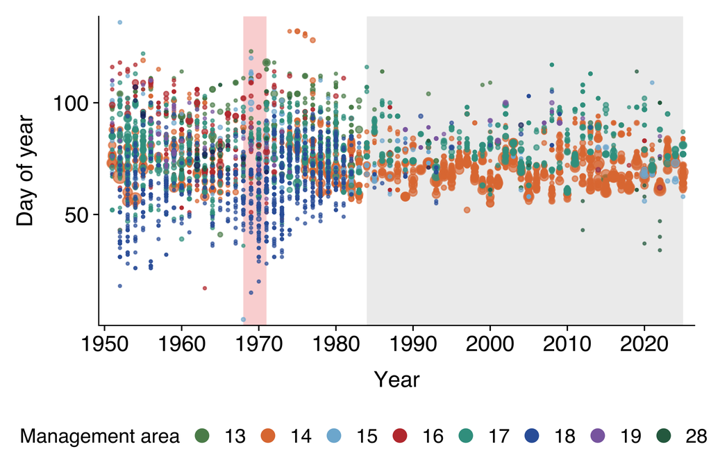

```r
## Supplementary Figure S1 - each point is a spawn event, placed by its start day
## of year and scaled by biomass, so the compression of the season is visible
## directly rather than only through the monthly shares tabulated above.
season_pts <- spawn_raw %>%
  filter(Region == SOG_REGION, StatisticalArea %in% OCC_AREAS, !is.na(StartDate)) %>%
  mutate(start  = suppressWarnings(as.Date(StartDate)),
         doy    = as.integer(format(start, "%j")),
         bio    = rowSums(cbind(Surface, Understory, Macrocystis), na.rm = TRUE),
         area_f = factor(as.character(StatisticalArea), levels = names(area_cols))) %>%
  filter(!is.na(doy), Year %in% 1951:2025, !is.na(area_f))

pS1 <- ggplot(season_pts, aes(Year, doy)) +
  geom_rect(data = shade_df, aes(xmin = xmin, xmax = xmax, ymin = ymin, ymax = ymax),
            inherit.aes = FALSE, fill = "grey85", alpha = 0.45) +
  band_closure() +
  geom_point(aes(size = bio, colour = area_f), alpha = 0.65) +
  scale_size_continuous(name = "Spawning biomass (t)", range = c(0.6, 5.5),
                        labels = label_number(big.mark = ",")) +
  scale_colour_manual(values = area_cols, name = "Management area") +
  scale_y_continuous(expand = expansion(mult = c(0.02, 0.02))) +
  labs(x = "Year", y = "Day of year") +
  common_panel_legend(pos = "bottom", just = "center") +
  guides(colour = guide_legend(override.aes = list(size = 5, alpha = 1), nrow = 1),
         size   = "none")

save_fig(pS1, "FigureS1_temporal_contraction")
pS1
```

## 6 Figure 1 - panels a, e and f

Panels **a**, **e** and **f** of Figure 1 are built here from the derived series, so the figure and the statistics above can never diverge (panels b, c and d are drawn by `Fig1_bcd_SoG_pipeline.R`). Panel **a** plots the same `SSB` column used by every model in this chapter: the sum of all spawn records (the DFO spawn index; §1 of chapter 01).

```r
## Catch by management area, with the TAC overlaid.
catch_area <- read_csv(file.path(DERIVED, "catch_decomposition.csv"), show_col_types = FALSE) %>%
  group_by(Year, area) %>%
  summarise(catch_kt = sum(catch_t, na.rm = TRUE)/1000, .groups = "drop") %>%
  mutate(area_f = factor(as.character(area), levels = names(area_cols))) %>%
  filter(!is.na(area_f), Year %in% 1951:2025)

tac <- read_csv(F_TAC, show_col_types = FALSE) %>%
  rename_with(trimws) %>%
  transmute(Year = as.numeric(New_Year), TAC_kt = as.numeric(TAC_metric_tons)/1000) %>%
  filter(!is.na(Year), Year %in% 1951:2025)

## Landed value: nominal and deflated to constant 2024 CAD.
value_two <- read_excel(F_VALUE, sheet = 1) %>%
  rename_with(trimws) %>%
  transmute(Year     = suppressWarnings(as.numeric(Year)),
            Nominal  = suppressWarnings(as.numeric(value_per_ton)),
            Real2024 = suppressWarnings(as.numeric(value_per_ton_real2024))) %>%
  filter(!is.na(Year), Year %in% 1950:2025) %>%
  group_by(Year) %>% summarise(across(everything(), ~mean(.x, na.rm = TRUE)), .groups = "drop") %>%
  mutate(across(c(Nominal, Real2024), ~ifelse(is.nan(.x) | .x <= 0, NA_real_, .x)))

cat(sprintf("Fig 1 inputs | SSB %d-%d | catch areas %d | TAC %d yr | value %d yr\n",
            min(d$Year), max(d$Year), n_distinct(catch_area$area_f),
            nrow(tac), sum(!is.na(value_two$Real2024))))
```

```
## Fig 1 inputs | SSB 1951-2024 | catch areas 9 | TAC 40 yr | value 74 yr
```

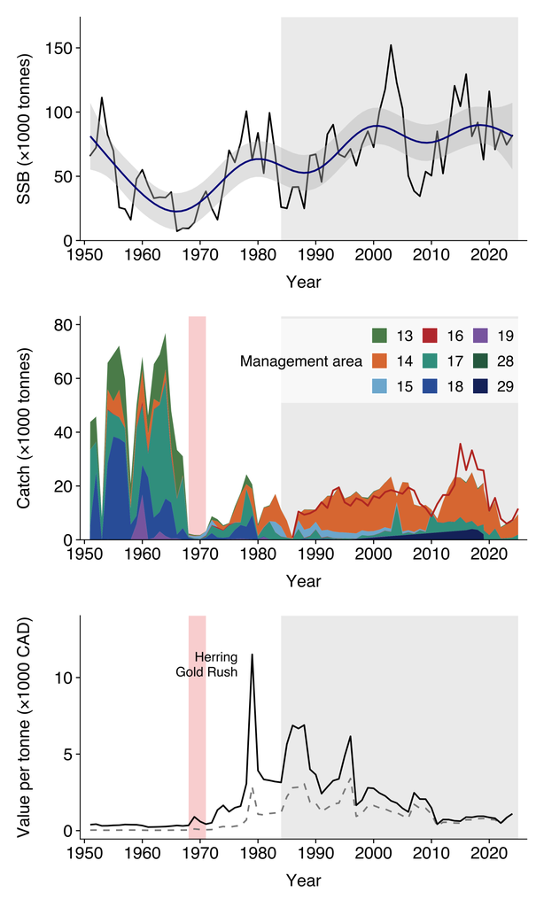

```r
shade_layer <- geom_rect(data = shade_df,
                         aes(xmin = xmin, xmax = xmax, ymin = ymin, ymax = ymax),
                         inherit.aes = FALSE, fill = "grey85", alpha = 0.45)

## ---- a  Spawning stock biomass ---------------------------------------------
p1a <- ggplot(d, aes(Year, SSBk)) +
  shade_layer +
  geom_line(linewidth = 0.9, lineend = "round") +
  geom_smooth(method = "gam", formula = y ~ s(x, k = 10), se = TRUE,
              colour = "darkblue", fill = "grey75", linewidth = 1) +
  scale_y_continuous(expand = expansion(mult = c(0.05, 0.15))) +
  labs(x = "Year", y = "SSB (×1000 tonnes)") +
  common_panel

## ---- e  Catch by management area, with TAC ---------------------------------
p1e <- ggplot(catch_area, aes(Year, catch_kt, fill = area_f)) +
  shade_layer + band_closure() +
  geom_area(colour = NA) +
  geom_line(data = tac, aes(Year, TAC_kt), inherit.aes = FALSE,
            colour = "#C0392B", linewidth = 1) +
  scale_fill_manual(values = area_cols, name = "Management area") +
  scale_y_continuous(expand = expansion(mult = c(0, 0.08))) +
  labs(x = "Year", y = "Catch (×1000 tonnes)") +
  common_panel_legend(pos = c(0.99, 0.99), just = c(1, 1)) +
  guides(fill = guide_legend(nrow = 3))

## ---- f  Landed value per tonne ---------------------------------------------
p1f <- ggplot(value_two, aes(Year)) +
  shade_layer + band_closure() +
  geom_line(aes(y = Nominal/1000),  colour = "grey55", linewidth = 0.9, linetype = "dashed") +
  geom_line(aes(y = Real2024/1000), colour = "black",  linewidth = 0.9) +
  annotate("text", x = 1976.5, y = max(value_two$Real2024, na.rm = TRUE)/1000,
           label = "Herring\nGold Rush", vjust = 0.9, hjust = 1, size = 5.5, lineheight = 0.95) +
  scale_y_continuous(expand = expansion(mult = c(0.05, 0.22))) +
  labs(x = "Year", y = "Value per tonne (×1000 CAD)") +
  common_panel

## panels b, c and d of Figure 1 are drawn by Fig1_bcd_SoG_pipeline.R
for (nm in c("a","e","f")) {
  save_fig(get(paste0("p1", nm)), paste0("Fig1", nm, "_",
    c(a="SSB", e="catch_by_area", f="value_per_tonne")[[nm]]))
}
p1a / p1e / p1f
```

## Sensitivity: SSB as per-location annual maxima

Main-text SSB is the sum of all spawn records (DFO spawn index). Because multiple records per location-year were far more common before the collapse, the biomass-occupancy model is repeated with SSB_max, the sum of per-location annual maxima.

```r
ann_s <- read_csv(file.path(DERIVED, "annual_series.csv"), show_col_types = FALSE) %>%
  mutate(phase = factor(if_else(Year < BREAK_YEAR, "Pre-collapse", "Post-collapse"),
                        levels = c("Pre-collapse", "Post-collapse")))
m_max <- lm(occupancy ~ scale(SSB_max) + phase, data = ann_s)
rng_max <- range(ann_s$SSB_max[ann_s$phase == "Pre-collapse"])
cat(sprintf("SSB_max sensitivity: SSB P = %.2f | phase P %s | occupancy pre %.0f%% vs post at matched SSB_max %.0f%%\n",
            summary(m_max)$coefficients["scale(SSB_max)", "Pr(>|t|)"],
            fmt_p(summary(m_max)$coefficients["phasePost-collapse", "Pr(>|t|)"]),
            100 * mean(ann_s$occupancy[ann_s$phase == "Pre-collapse"]),
            100 * mean(ann_s$occupancy[ann_s$phase == "Post-collapse" &
                                         ann_s$SSB_max >= rng_max[1] & ann_s$SSB_max <= rng_max[2]])))
```

```
## SSB_max sensitivity: SSB P = 0.61 | phase P < 0.001 | occupancy pre 66% vs post at matched SSB_max 32%
```

```r
loc_multi <- read_csv(file.path(DERIVED, "site_year_spawn_all.csv"), show_col_types = FALSE) %>%
  mutate(era = if_else(Year < BREAK_YEAR, "pre", "post")) %>% group_by(era) %>%
  summarise(pct_multi_record = round(100 * mean(n_records > 1)), .groups = "drop")
print(loc_multi)
```

```
## # A tibble: 2 × 2
##   era   pct_multi_record
##   <chr>            <dbl>
## 1 post                13
## 2 pre                 50
```